# SSU_classifier

csbl_cmkim

2023-06-12

##### 0-1. loading library

분석에 필요한 라이브러리 로드.

```r
#install.packages("https://cran.r-project.org/src/contrib/Archive/BiocManager/BiocManager_1.30.19.tar.gz", repos = NULL, type="source")
#BiocManager::install("DNAStringSet")
library(dplyr)
library(ggplot2)
library(ISLR)
library(MASS)
library(glmnet)
library(randomForest)
library(gbm)
library(rpart)
library(boot)
library(data.table)
library(ROCR)
library(gridExtra)
library(tidyr)
library(stringr)
library(Biostrings)
library(psych)
library(tictoc)
```

##### 0-2. defining function

분석에 필요한 함수 정의.

```r
#binomial_deviance function
binomial_deviance <- function(y_obs, yhat){
  epsilon = 0.0001
  yhat = ifelse(yhat < epsilon, epsilon, yhat)
  yhat = ifelse(yhat > 1-epsilon, 1-epsilon, yhat)
  a = ifelse(y_obs==0, 0, y_obs * log(y_obs/yhat))
  b = ifelse(y_obs==1, 0, (1-y_obs) * log((1-y_obs)/(1-yhat)))
  return(2*sum(a + b))
}

#predict.cv.glmnet function
predict.cv.glmnet=function(object,newx,s=c("lambda.1se","lambda.min"),...){
  if(is.numeric(s))lambda=s
  else
    if(is.character(s)){
      s=match.arg(s)
      lambda=object[[s]]
      names(lambda)=s
    }
  else stop("Invalid form for s")
  predict(object$glmnet.fit,newx,s=lambda,...)
}


#panel.cor function
panel.cor <- function(x, y, digits = 2, prefix = "", cex.cor, ...)
{
  usr <- par("usr"); on.exit(par(usr))
  par(usr = c(0, 1, 0, 1))
  r <- abs(cor(x, y))
  txt <- format(c(r, 0.123456789), digits = digits)[1]
  txt <- paste0(prefix, txt)
  if(missing(cex.cor)) cex.cor <- 0.8/strwidth(txt)
  text(0.5, 0.5, txt, cex = cex.cor * r)
}
```

##### 1. loading data

데이터 로딩  
학습에 사용한 데이터는 16S-ITGDB (integrated database) 로 원핵생물의 16S rRNA 서열 기반 분류에 필요한 데이터 모음으로 각 종의 분류와 16S 서열이 나열되어 있다.  
https://github.com/yphsieh/16S-ITGDB/tree/master/data

##### 1-1. loading taxa

종 분류 정보

```r
seq_itgdb_taxa <- read.csv("/Users/chungminkim/Downloads/drive-download-20230604T125759Z-001/seq_itgdb_taxa.txt",
                           sep='\t', header=F)
taxa <- separate(seq_itgdb_taxa, V2, into = c('kingdom', 'phylum', 'class', 'order', 'family', 'genus', 'species'), sep = ";")
colnames(taxa)[c(1)] <- c('id')
glimpse(taxa)
```

```
## Rows: 486,640
## Columns: 8
## $ id      <chr> "AJ000684", "EF599163", "546984", "AY859683", "AY883036", "DQ6…
## $ kingdom <chr> "bacteria", "bacteria", "bacteria", "bacteria", "bacteria", "b…
## $ phylum  <chr> "actinobacteria", "proteobacteria", "proteobacteria", "actinob…
## $ class   <chr> "actinobacteria", "gammaproteobacteria", "gammaproteobacteria"…
## $ order   <chr> "mycobacteriales", "vibrionales", "vibrionales", "mycobacteria…
## $ family  <chr> "mycobacteriaceae", "vibrionaceae", "vibrionaceae", "mycobacte…
## $ genus   <chr> "mycobacterium", "vibrio", "vibrio", "mycobacterium", "acetoba…
## $ species <chr> "heidelbergense", "atlanticus", "atlanticus", "aubagnense", "s…
```

##### 1-2. loading sequences

각 종의 16S 서열 정보

```r
seq_itgdb_seq <- readDNAStringSet("/Users/chungminkim/Downloads/drive-download-20230604T125759Z-001/seq_itgdb_seq.fasta")
id_sequence = data.frame(id=names(seq_itgdb_seq),sequences=as.character(seq_itgdb_seq))
glimpse(id_sequence)
```

```
## Rows: 486,640
## Columns: 2
## $ id        <chr> "AJ000684", "EF599163", "546984", "AY859683", "AY883036", "D…
## $ sequences <chr> "GAACGCTGGCGGCGTGCTTAACACATGCAAGTCGAACGGAAAGGTCTCTTCGGAGATAC…
```

```r
# 486640 16S sequence in total
```

##### 1-3. processing data & counting frequency

로딩한 두 데이터를 합치고 phylum 단위에서 분류한다.

```r
phylum_seq <- cbind(taxa[,3], id_sequence[,2])
colnames(phylum_seq) <- c('phylum', 'sequence')
phylum_seq <- as_tibble(phylum_seq)
glimpse(phylum_seq)
```

```
## Rows: 486,640
## Columns: 2
## $ phylum   <chr> "actinobacteria", "proteobacteria", "proteobacteria", "actino…
## $ sequence <chr> "GAACGCTGGCGGCGTGCTTAACACATGCAAGTCGAACGGAAAGGTCTCTTCGGAGATACT…
```

phylum의 수 및 분포  
proteobacteria, firmicutes, bacteroidota, actinobacteriota의 시퀀스가 압도적으로 많다.

```r
phylum_seq <- phylum_seq %>% filter(!is.na(phylum))
phylum_seq %>% summarize(n_phylum = n_distinct(phylum)) # number of phylum: 317
```

```
## # A tibble: 1 × 1
##   n_phylum
##      <int>
## 1      317
```

```r
taxa %>% group_by(phylum) %>% count(sort=T) # frequency table
```

```
## # A tibble: 318 × 2
## # Groups:   phylum [318]
##    phylum                n
##    <chr>             <int>
##  1 proteobacteria   123749
##  2 firmicutes       112963
##  3 bacteroidota      41772
##  4 actinobacteriota  29995
##  5 cyanobacteria     10390
##  6 chloroflexi        9368
##  7 actinobacteria     8944
##  8 arthropoda         8770
##  9 acidobacteriota    8706
## 10 bacteroidetes      8257
## # ℹ 308 more rows
```

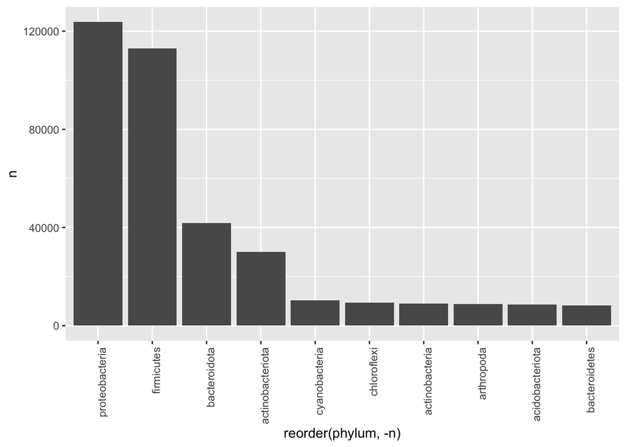

```r
phyla = taxa %>% group_by(phylum) %>% count(sort=T)
ggplot(phyla[1:10,], aes(reorder(phylum, -n),n)) +
  geom_bar(stat='identity') +
  theme(axis.text.x = element_text(angle = 90, hjust = 1))
```

```r
# proteobacteria, firmicutes, bacteroidota, actinobacteriota, ....


phylum_table <- phylum_seq %>% group_by(phylum) %>%
  summarize(Freq=n_distinct(sequence))
phylum_table <- phylum_table %>% filter(row_number() <= n()-1) # remove NA


# number of phyla which have more than 100, 1000, 10000 freq
phylum_table %>%
  summarize(more_than_100 = n_distinct(phylum_table %>% filter(Freq > 100)),
            more_than_1000 = n_distinct(phylum_table %>% filter(Freq > 1000)),
            more_than_10000 = n_distinct(phylum_table %>% filter(Freq > 10000))
  ) #120, 38, 5
```

```
## # A tibble: 1 × 3
##   more_than_100 more_than_1000 more_than_10000
##           <int>          <int>           <int>
## 1           119             38               5
```

##### 2-1. example1: firmicutes

먼저 데이터 중 임의로 20,000개의 서열을 고른다. 이 20,000개의 서열 내에 firmicutes 속의 서열은 몇개인지 확인한다.

```r
# randomly selecting 20,000 sequence
data <- phylum_seq %>% sample_n(20000)

#number of firmicutes sequence and others
data %>%
  summarize(n_firmicutes = n_distinct(data %>% filter(phylum == "firmicutes")),
            n_others = n_distinct(data %>% filter(phylum != "firmicutes")))
```

```
## # A tibble: 1 × 2
##   n_firmicutes n_others
##          <int>    <int>
## 1         4627    15373
```

여기서 뽑은 서열정보를 이용해서 학습을 진행할 것이다.  
각 서열의 mono-, di-, trimer 조성 정보를 데이터에 추가한다.

```r
# counting nucleotide mono, di, trimer
r16Sstr <- DNAStringSet(data$sequence)
k1fq = alphabetFrequency(r16Sstr)
k1fq = k1fq[,1:4]
k2fq = dinucleotideFrequency(r16Sstr)
k3fq = trinucleotideFrequency(r16Sstr)
#k4fq = oligonucleotideFrequency(r16Sstr, width=4)
#k5fq = oligonucleotideFrequency(r16Sstr, width=5)
data <- cbind(data[,1], k1fq, k2fq, k3fq)
colnames(data)[1]<-'phylum'
head(data[1:10])
```

```
##             phylum   A   C   G   T  AA AC  AG AT CA
## 1   proteobacteria 363 322 458 308  97 88 111 67 81
## 2       firmicutes 361 325 435 270 110 86  99 65 80
## 3 actinobacteriota 309 368 498 258  83 80  94 52 76
## 4 actinobacteriota 314 313 475 316  85 78  89 61 70
## 5 desulfobacterota 342 303 426 288 104 70 102 66 73
## 6       firmicutes 371 307 436 277 108 91 103 69 84
```

이항연산을 진행하기 위해 firmicutes를 기준으로 phylum을 0 혹은 1로 바꾼다. (firmicutes는 0, 아니면 1)

```r
data$phylum <- factor(ifelse(data$phylum == 'firmicutes', 0, 1))
head(data[1:10])
```

```
##   phylum   A   C   G   T  AA AC  AG AT CA
## 1      1 363 322 458 308  97 88 111 67 81
## 2      0 361 325 435 270 110 86  99 65 80
## 3      1 309 368 498 258  83 80  94 52 76
## 4      1 314 313 475 316  85 78  89 61 70
## 5      1 342 303 426 288 104 70 102 66 73
## 6      0 371 307 436 277 108 91 103 69 84
```

##### 2-2. example1 running

```r
data2 <- data
colnames(data2)[1]<-'phylum'



#TRAINING
set.seed(2306)
n <- nrow(data2)
idx <- 1:n
training_idx <- sample(idx, n * .60)
idx <- setdiff(idx, training_idx)
validate_idx <- sample(idx, n * .20)
test_idx <- setdiff(idx, validate_idx)
training <- data2[training_idx,]
validation <- data2[validate_idx,]
test <- data2[test_idx,]


#LOGISTIC REGRESSION
tic("LOGISTIC")
data2_lm_full <- glm(phylum ~ ., data=training, family=binomial)
summary.glm(data2_lm_full)
```

```
##
## Call:
## glm(formula = phylum ~ ., family = binomial, data = training)
##
## Coefficients:
##             Estimate Std. Error z value Pr(>|z|)
## (Intercept)  4.63714    1.13868   4.072 4.65e-05 ***
## A           -0.70924    1.41739  -0.500    0.617
## C           -0.09910    1.01574  -0.098    0.922
## G           -1.18527    0.93770  -1.264    0.206
## T           -1.08406    1.29323  -0.838    0.402
## AA           2.03096    2.85406   0.712    0.477
## AC           1.39342    1.74561   0.798    0.425
## AG           2.06359    1.77492   1.163    0.245
## AT           2.56518    1.99105   1.288    0.198
## CA           0.40704    1.73173   0.235    0.814
## CC           0.35052    2.10443   0.167    0.868
## CG           0.91121    1.49476   0.610    0.542
## CT           0.93554    1.67915   0.557    0.577
## GA           1.57807    1.77428   0.889    0.374
## GC           1.61526    1.39096   1.161    0.246
## GG           2.34173    1.93439   1.211    0.226
## GT           1.24196    1.71016   0.726    0.468
## TA           2.71662    2.01848   1.346    0.178
## TC           1.40171    1.71487   0.817    0.414
## TG           2.32153    1.69638   1.369    0.171
## TT           2.25145    2.63248   0.855    0.392
## AAA         -1.36839    1.45098  -0.943    0.346
## AAC         -0.80947    1.46510  -0.553    0.581
## AAG         -0.44654    1.43835  -0.310    0.756
## AAT         -0.62903    1.44937  -0.434    0.664
## ACA         -1.25676    1.12868  -1.113    0.266
## ACC         -0.33157    1.12698  -0.294    0.769
## ACG         -0.30586    1.16145  -0.263    0.792
## ACT         -0.20969    1.12012  -0.187    0.851
## AGA         -1.18725    0.99570  -1.192    0.233
## AGC         -1.54018    1.01455  -1.518    0.129
## AGG         -1.21024    1.03508  -1.169    0.242
## AGT         -0.68104    1.01271  -0.672    0.501
## ATA         -1.97995    1.37134  -1.444    0.149
```

[output cut: 46 more lines]

```
## TGT         -0.45353    0.98981  -0.458    0.647
## TTA         -1.77783    1.39713  -1.272    0.203
## TTC         -1.51779    1.43841  -1.055    0.291
## TTG         -1.31027    1.40322  -0.934    0.350
## TTT         -1.10372    1.36233  -0.810    0.418
## ---
## Signif. codes:  0 '***' 0.001 '**' 0.01 '*' 0.05 '.' 0.1 ' ' 1
##
## (Dispersion parameter for binomial family taken to be 1)
##
##     Null deviance: 12976  on 11999  degrees of freedom
## Residual deviance:  2072  on 11915  degrees of freedom
## AIC: 2242
##
## Number of Fisher Scoring iterations: 9
```

```r
predict(data2_lm_full, newdata = data2[1:5,], type='response')
```

```
##          1          2          3          4          5
## 0.99977721 0.04085119 0.99999825 0.99987361 0.46688214
```

```r
LOGISTIC_time <- toc()
```

```
## LOGISTIC: 0.846 sec elapsed
```

```r
contribution <- as.data.frame(data2_lm_full$coefficients)
modified_contribution <- as.data.frame(cbind(nucleotide = rownames(contribution), score = contribution[, 1]))
sorted_contribution <- modified_contribution[rev(order(modified_contribution[, 2])),]
print(sorted_contribution[2:6, ])
```

```
##    nucleotide            score
## 18         TA 2.71662184168586
## 9          AT 2.56518276529472
## 16         GG 2.34173475716283
## 20         TG 2.32153279079201
## 21         TT 2.25145288130052
```

```r
#MODEL EVALUATION
y_obs <- as.numeric(as.character(validation$phylum))
yhat_lm <- predict(data2_lm_full, newdata = validation, type='response')
pred_lm <- prediction(as.numeric(yhat_lm), as.numeric(y_obs))
#performance(pred_lm, "auc")@y.values[[1]]
#binomial_deviance(y_obs, yhat_lm)
#plot(performance(pred_lm, measure="tpr", x.measure='fpr'))
cbind(as.data.frame(data2[1:5, 1]),
      as.data.frame(predict(data2_lm_full, newdata = data2[1:5,], type='response')))
```

```
##   data2[1:5, 1]
## 1             1
## 2             0
## 3             1
## 4             1
## 5             1
##   predict(data2_lm_full, newdata = data2[1:5, ], type = "response")
## 1                                                        0.99977721
## 2                                                        0.04085119
## 3                                                        0.99999825
## 4                                                        0.99987361
## 5                                                        0.46688214
```

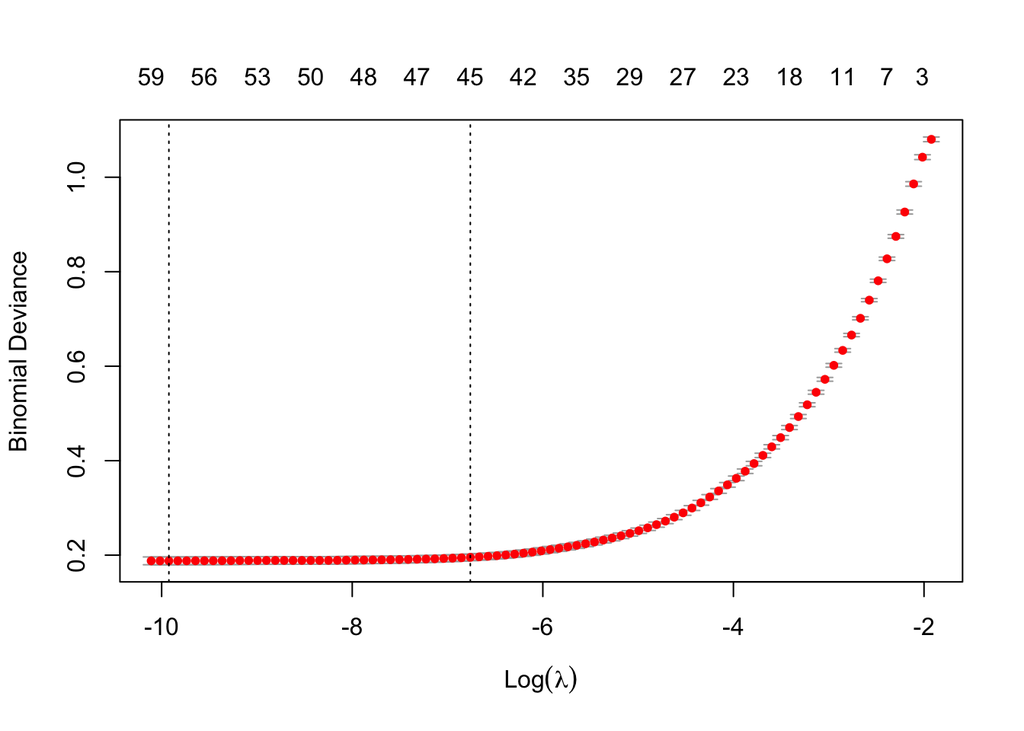

```r
#LASSO MODEL
xx <- model.matrix(phylum ~ .-1, data2)
x <- xx[training_idx, ]
y <- as.numeric(as.character(training$phylum))
#glimpse(x)


tic("LASSO")
data2_cvfit <- cv.glmnet(x, y, family = "binomial")

plot(data2_cvfit)
```

```r
LASSO_time <- toc()
```

```
## LASSO: 9.456 sec elapsed
```

```r
#coef(data2_cvfit, s = c("lambda.1se"))
length(which(coef(data2_cvfit, s ="lambda.min")>0)) #50
```

```
## [1] 32
```

다섯개 서열에 대해서 예상

```r
#MODEL EVALUATION
predict.cv.glmnet(data2_cvfit, s='lambda.min', newx = x[1:5,], type='response')
```

```
##       lambda.min
## 19791  0.4813180
## 7309   0.9987001
## 5216   0.9978882
## 6375   0.9597747
## 4058   0.9997078
```

```r
predi <- as.data.frame(predict.cv.glmnet(data2_cvfit, s='lambda.min', newx = x[1:5,], type='response'))
cbind(data2[as.numeric(rownames(x[1:5,])), 1], predi)
```

```
##       data2[as.numeric(rownames(x[1:5, ])), 1] lambda.min
## 19791                                        0  0.4813180
## 7309                                         1  0.9987001
## 5216                                         1  0.9978882
## 6375                                         1  0.9597747
## 4058                                         1  0.9997078
```

```r
yhat_glmnet <- predict(data2_cvfit, s="lambda.min", newx=xx[validate_idx,],
                       type='response')
yhat_glmnet <- yhat_glmnet[,1]
pred_glmnet <- prediction(yhat_glmnet, y_obs)
#performance(pred_glmnet, "auc")@y.values[[1]]
#binomial_deviance(y_obs, yhat_glmnet)
```

나무 모델

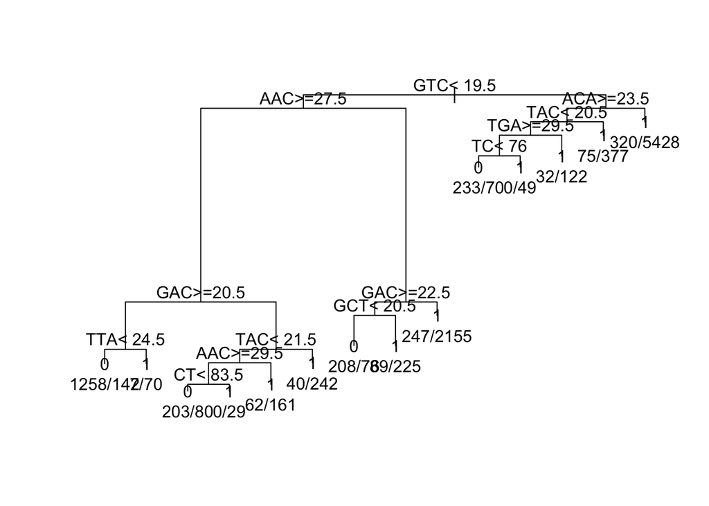

```r
#TREE MODEL
data2_tr <- rpart(phylum ~ ., data = training)
#data2_tr

#printcp(data2_tr)
#summary(data2_tr)

opar <- par(mfrow = c(1,1), xpd = NA)
plot(data2_tr)
text(data2_tr, use.n = T)
```

```r
par(opar)

#EVALUATION
yhat_tr <- predict(data2_tr, validation)
yhat_tr <- yhat_tr[,"1"]
pred_tr <- prediction(yhat_tr, y_obs)
#performance(pred_tr, "auc")@y.values[[1]]
#binomial_deviance(y_obs, yhat_tr)
```

랜덤 포레스트

```r
#RANDOM FOREST
set.seed(2305)
tic("RF")
data2_rf <- randomForest(phylum ~., training)
#data2_rf
RF_time <- toc()
```

```
## RF: 24.025 sec elapsed
```

```r
#opar <- par(mfrow=c(1,2))
#plot(data2_rf)
#varImpPlot(data2_rf)
#par(opar)

#EVALUATION
yhat_rf <- predict(data2_rf, newdata=validation, type='prob')[,'1']
pred_rf <- prediction(yhat_rf, y_obs)
#performance(pred_rf, "auc")@y.values[[1]]
#binomial_deviance(y_obs, yhat_rf)
```

부스팅

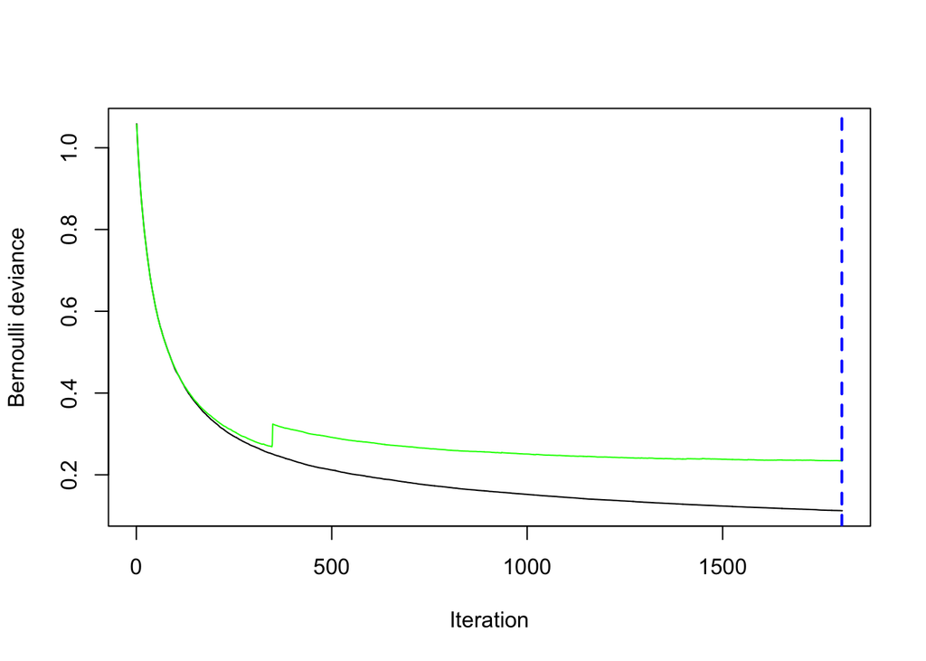

```
## [1] 1805
```

```r
#BOOSTING
set.seed(2305)
tic("BOOSTING")
data2_for_gbm <-
  training %>%
  mutate(phylum=as.numeric(as.character(phylum)))
data2_gbm <- gbm(phylum ~ .,
                           data = data2_for_gbm, distribution="bernoulli",
                           n.trees=1806,
                           n.minobsinnode = 1,
                           cv.folds=3,
                           verbose=T)
(best_iter = gbm.perf(data2_gbm, method="cv")) #1806
```

```r
BOOSTING_time <- toc()
```

```
## BOOSTING: 27.32 sec elapsed
```

```r
#EVALUATION
yhat_gbm <- predict(data2_gbm, n.trees=best_iter, newdata=validation, type='response')
pred_gbm <- prediction(yhat_gbm, y_obs)
#performance(pred_gbm, "auc")@y.values[[1]]
#binomial_deviance(y_obs, yhat_gbm)
```

각 모델에 소요된 시간과 정확도를 확인한다. AUC, bin_dev, time 비교

```r
#최종 모형 선택과 테스트세트 오차 계산
(ex1_final <- data.frame(method=c('lm', 'glmnet', 'rf', 'gbm'),
           time = c(LOGISTIC_time$callback_msg,
                    LASSO_time$callback_msg,
                    RF_time$callback_msg,
                    BOOSTING_time$callback_msg),
           auc = c(performance(pred_lm, "auc")@y.values[[1]],
                   performance(pred_glmnet, "auc")@y.values[[1]],
                   performance(pred_rf, "auc")@y.values[[1]],
                   performance(pred_gbm, "auc")@y.values[[1]]),
           bin_dev = c(binomial_deviance(y_obs, yhat_lm),
                       binomial_deviance(y_obs, yhat_glmnet),
                       binomial_deviance(y_obs, yhat_rf),
                       binomial_deviance(y_obs, yhat_gbm))))
```

```
##   method                        time       auc   bin_dev
## 1     lm LOGISTIC: 0.846 sec elapsed 0.9894948  806.6201
## 2 glmnet    LASSO: 9.456 sec elapsed 0.9899495  784.4291
## 3     rf      RF: 24.025 sec elapsed 0.9941032 1144.1077
## 4    gbm BOOSTING: 27.32 sec elapsed 0.9929736  680.5124
```

모든 모델에서 높은 auc 값을 얻을 수 있다. 소요시간은 로지스틱 << LASSO < 랜덤포레스트 < 부스팅 순이다.

ROC curve

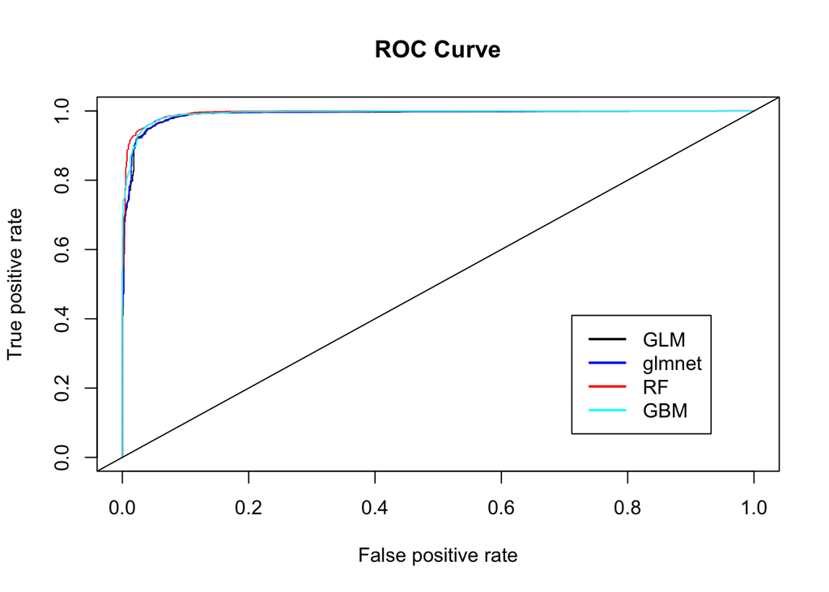

```r
#ROC curve
perf_lm <- performance(pred_lm, measure = "tpr", x.measure = "fpr")
perf_glmnet <- performance(pred_glmnet, measure = "tpr", x.measure = "fpr")
perf_rf <- performance(pred_rf, measure = "tpr", x.measure = "fpr")
perf_gbm <- performance(pred_gbm, measure = "tpr", x.measure = "fpr")

plot(perf_lm, col='black', main="ROC Curve")
plot(perf_glmnet, add=T, col='blue')
plot(perf_rf, add=T, col='red')
plot(perf_gbm, add=T, col='cyan')
abline(0,1)
legend('bottomright', inset=.1,
       legend=c("GLM", "glmnet", "RF", "GBM"),
       col=c('black', 'blue', 'red', 'cyan'), lty=1, lwd=2)
```

네가지 모형 모두 auc 값이 높기때문에 ROC curve 또한 좌상단으로 치우쳐 있다.

##### 2-3. example2: firmicutes & others with collapsed 5mer

임의로 20,000개의 서열을 추출하고 firmicutes 속을 기준으로 나눈다.  
pentamer nucleotide 서열 정보를 추가한다.

```r
# example2 : firmicutes & others with collasped 5 mer
data <- phylum_seq %>% sample_n(20000)
data %>%
  summarize(n_firmicutes = n_distinct(data %>% filter(phylum == "firmicutes")),
            n_others = n_distinct(data %>% filter(phylum != "firmicutes")))
```

```
## # A tibble: 1 × 2
##   n_firmicutes n_others
##          <int>    <int>
## 1         4659    15340
```

```r
# counting nucleotide pentamer
r16Sstr <- DNAStringSet(data$sequence)
#k1fq = alphabetFrequency(r16Sstr)
#k1fq = k1fq[,1:4]
#k2fq = dinucleotideFrequency(r16Sstr)
#k3fq = trinucleotideFrequency(r16Sstr)
#k4fq = oligonucleotideFrequency(r16Sstr, width=4)
k5fq = oligonucleotideFrequency(r16Sstr, width=5)

#data <- cbind(data[,1], k1fq, k2fq, k3fq, k4fq, k5fq)
data <- cbind(data[,1], k5fq)
colnames(data)[1]<-'phylum'
data$phylum <- factor(ifelse(data$phylum == 'firmicutes', 0, 1))
head(data)[1:10]
```

```
##   phylum AAAAA AAAAC AAAAG AAAAT AAACA AAACC AAACG AAACT AAAGA
## 1      1     1     3     1     0     0     4     1     1     1
## 2      1     1     2     0     1     1     1     1     4     0
## 3      1     0     0     0     0     1     1     2     2     0
## 4      1     0     0     0     0     1     2     0     3     0
## 5      0     1     2     2     0     2     2     3     2     2
## 6      0     0     1     0     0     2     1     2     2     0
```

우선 이 서열 정보를 모두 사용하여 분석을 진행한다.

```r
data2 <- data
```

#####example2 running

```r
#TRAINING
set.seed(2306)
n <- nrow(data2)
idx <- 1:n
training_idx <- sample(idx, n * .60)
idx <- setdiff(idx, training_idx)
validate_idx <- sample(idx, n * .20)
test_idx <- setdiff(idx, validate_idx)
training <- data2[training_idx,]
validation <- data2[validate_idx,]
test <- data2[test_idx,]


#LOGISTIC REGRESSION
tic("LOGISTIC")
data2_lm_full <- glm(phylum ~ ., data=training, family=binomial)
#summary.glm(data2_lm_full)
LOGISTIC_time <- toc()
```

```
## LOGISTIC: 219.47 sec elapsed
```

```r
cbind(as.data.frame(data2[1:5, 1]),
      as.data.frame(predict(data2_lm_full, newdata = data2[1:5,], type='response')))
```

```
##   data2[1:5, 1]
## 1             1
## 2             1
## 3             1
## 4             1
## 5             0
##   predict(data2_lm_full, newdata = data2[1:5, ], type = "response")
## 1                                                      1.000000e+00
## 2                                                      1.000000e+00
## 3                                                      1.000000e+00
## 4                                                      1.000000e+00
## 5                                                      2.220446e-16
```

```r
contribution <- as.data.frame(data2_lm_full$coefficients)
modified_contribution <- as.data.frame(cbind(nucleotide = rownames(contribution), score = contribution[, 1]))
sorted_contribution <- modified_contribution[rev(order(modified_contribution[, 2])),]
print(sorted_contribution[2:6, ])
```

```
##     nucleotide            score
## 910      TGATA  9.8818630753377
## 90       ACCGA  9.8540122849281
## 761      GTTCT 9.70725574858424
## 968      TTACG  9.6599055428277
## 493      CTGGT 9.63858720552316
```

```r
#MODEL EVALUATION
y_obs <- as.numeric(as.character(validation$phylum))
yhat_lm <- predict(data2_lm_full, newdata = validation, type='response')
pred_lm <- prediction(as.numeric(yhat_lm), as.numeric(y_obs))
#performance(pred_lm, "auc")@y.values[[1]]
#binomial_deviance(y_obs, yhat_lm)
#plot(performance(pred_lm, measure="tpr", x.measure='fpr'))
```

LASSO 모델.

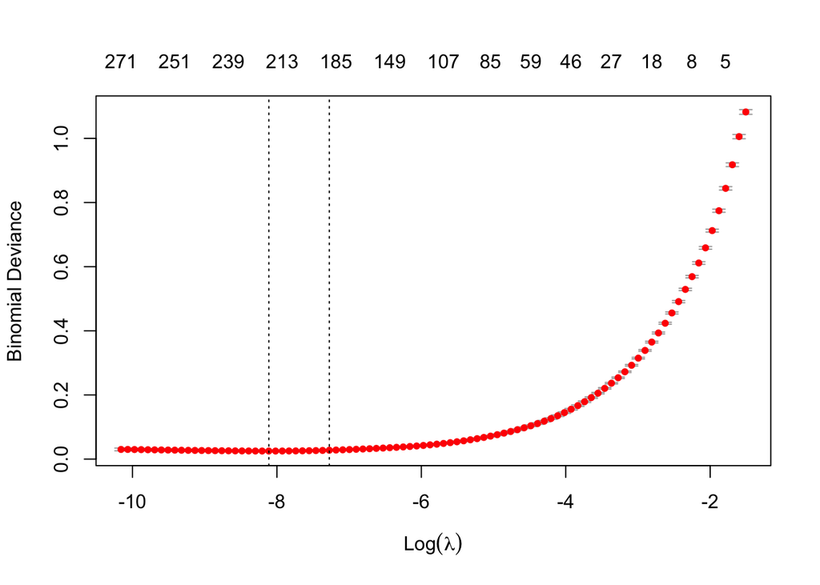

```r
#LASSO MODEL
xx <- model.matrix(phylum ~ .-1, data2)
x <- xx[training_idx, ]
y <- as.numeric(as.character(training$phylum))
#glimpse(x)


tic("LASSO")
data2_cvfit <- cv.glmnet(x, y, family = "binomial")

plot(data2_cvfit)
```

```r
LASSO_time <- toc()
```

```
## LASSO: 18.317 sec elapsed
```

```r
#coef(data2_cvfit, s = c("lambda.1se"))
length(which(coef(data2_cvfit, s ="lambda.min")>0)) #141
```

```
## [1] 114
```

```r
#MODEL EVALUATION
predi <- as.data.frame(predict.cv.glmnet(data2_cvfit, s='lambda.min', newx = x[1:5,], type='response'))
cbind(data2[as.numeric(rownames(x[1:5,])), 1], predi)
```

```
##       data2[as.numeric(rownames(x[1:5, ])), 1]   lambda.min
## 19791                                        1 0.9999960555
## 7309                                         0 0.0004637538
## 5216                                         1 0.9999865068
## 6375                                         1 0.9999989248
## 4058                                         1 0.9999536733
```

```r
yhat_glmnet <- predict(data2_cvfit, s="lambda.min", newx=xx[validate_idx,],
                       type='response')
yhat_glmnet <- yhat_glmnet[,1]
pred_glmnet <- prediction(yhat_glmnet, y_obs)
#performance(pred_glmnet, "auc")@y.values[[1]]
#binomial_deviance(y_obs, yhat_glmnet)
```

[output not shown]

[figure not shown]

```r
par(opar)

#EVALUATION
yhat_tr <- predict(data2_tr, validation)
yhat_tr <- yhat_tr[,"1"]
pred_tr <- prediction(yhat_tr, y_obs)
#performance(pred_tr, "auc")@y.values[[1]]
#binomial_deviance(y_obs, yhat_tr)
```

랜덤 포레스트

```r
#RANDOM FOREST
set.seed(2305)
tic("RF")
data2_rf <- randomForest(phylum ~., training)
#data2_rf
RF_time <- toc()
```

```
## RF: 373.869 sec elapsed
```

```r
#opar <- par(mfrow=c(1,2))
#plot(data2_rf)
#varImpPlot(data2_rf)
#par(opar)

#EVALUATION
yhat_rf <- predict(data2_rf, newdata=validation, type='prob')[,'1']
pred_rf <- prediction(yhat_rf, y_obs)
#performance(pred_rf, "auc")@y.values[[1]]
#binomial_deviance(y_obs, yhat_rf)
```

부스팅

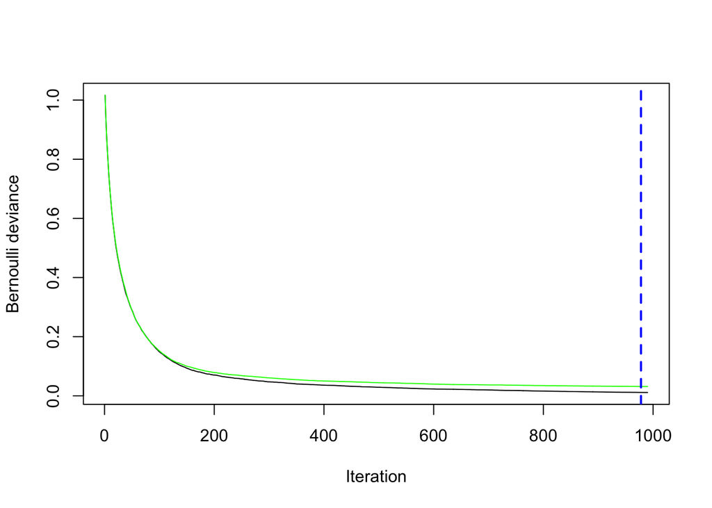

```
## [1] 978
```

```r
#BOOSTING
set.seed(2305)
tic("BOOSTING")
data2_for_gbm <-
  training %>%
  mutate(phylum=as.numeric(as.character(phylum)))
data2_gbm <- gbm(phylum ~ .,
                           data = data2_for_gbm, distribution="bernoulli",
                           n.trees=990,
                           n.minobsinnode = 1,
                           cv.folds=3,
                           verbose=T)
(best_iter = gbm.perf(data2_gbm, method="cv")) #990
```

```r
BOOSTING_time <- toc()
```

```
## BOOSTING: 1079.283 sec elapsed
```

```r
#EVALUATION
yhat_gbm <- predict(data2_gbm, n.trees=best_iter, newdata=validation, type='response')
pred_gbm <- prediction(yhat_gbm, y_obs)
#performance(pred_gbm, "auc")@y.values[[1]]
#binomial_deviance(y_obs, yhat_gbm)
```

```r
(ex2_final <- data.frame(method=c('lm', 'glmnet', 'rf', 'gbm'),
           time = c(LOGISTIC_time$callback_msg,
                    LASSO_time$callback_msg,
                    RF_time$callback_msg,
                    BOOSTING_time$callback_msg),
           auc = c(performance(pred_lm, "auc")@y.values[[1]],
                   performance(pred_glmnet, "auc")@y.values[[1]],
                   performance(pred_rf, "auc")@y.values[[1]],
                   performance(pred_gbm, "auc")@y.values[[1]]),
           bin_dev = c(binomial_deviance(y_obs, yhat_lm),
                       binomial_deviance(y_obs, yhat_glmnet),
                       binomial_deviance(y_obs, yhat_rf),
                       binomial_deviance(y_obs, yhat_gbm))))
```

```
##   method                           time       auc  bin_dev
## 1     lm   LOGISTIC: 219.47 sec elapsed 0.9990533 238.8066
## 2 glmnet      LASSO: 18.317 sec elapsed 0.9997186 113.6695
## 3     rf        RF: 373.869 sec elapsed 0.9996336 576.5199
## 4    gbm BOOSTING: 1079.283 sec elapsed 0.9995689 139.3133
```

##### 2-4. example3: firmicutes & others with collapsed 5mer

임의로 20,000개의 서열을 추출하고 firmicutes 속을 기준으로 나눈다.  
pentamer nucleotide 서열 정보를 추가한다.

```r
# example2 : firmicutes & others with collasped 5 mer
data <- phylum_seq %>% sample_n(20000)
data %>%
  summarize(n_firmicutes = n_distinct(data %>% filter(phylum == "firmicutes")),
            n_others = n_distinct(data %>% filter(phylum != "firmicutes")))
```

```
## # A tibble: 1 × 2
##   n_firmicutes n_others
##          <int>    <int>
## 1         4569    15431
```

```r
# counting nucleotide pentamer
r16Sstr <- DNAStringSet(data$sequence)
#k1fq = alphabetFrequency(r16Sstr)
#k1fq = k1fq[,1:4]
#k2fq = dinucleotideFrequency(r16Sstr)
#k3fq = trinucleotideFrequency(r16Sstr)
#k4fq = oligonucleotideFrequency(r16Sstr, width=4)
k5fq = oligonucleotideFrequency(r16Sstr, width=5)

#data <- cbind(data[,1], k1fq, k2fq, k3fq, k4fq, k5fq)
data <- cbind(data[,1], k5fq)
colnames(data)[1]<-'phylum'
data$phylum <- factor(ifelse(data$phylum == 'firmicutes', 0, 1))
head(data)[1:10]
```

```
##   phylum AAAAA AAAAC AAAAG AAAAT AAACA AAACC AAACG AAACT AAAGA
## 1      0     1     3     0     0     2     2     2     4     1
## 2      1     1     3     1     0     0     2     1     3     2
## 3      1     0     0     1     0     0     0     2     3     1
## 4      1     0     2     3     0     1     2     1     2     1
## 5      1     0     1     0     0     2     0     1     4     1
## 6      0     2     5     0     1     1     3     3     4     1
```

이 서열 정보중 높은 상관관계에 있는 서열은 제외한다. correlation 상수값 0.29는 변수가 150개 정도가 되도록 하는 값이다.

```r
#pairs.panels(data[,c(2:11)],
#             method = "pearson",
#             hist.col = "#00AFBB",
#             density = TRUE,
#             ellipses = TRUE)
library(tictoc)
tic("correlation")
cor_matrix <- cor(data[,c(2:1025)])
cor_time <- toc()
```

```
## correlation: 9.264 sec elapsed
```

```r
data.frame(time=cor_time$callback_msg)
```

```
##                             time
## 1 correlation: 9.264 sec elapsed
```

```r
cor_matrix_rm <- cor_matrix
cor_matrix_rm[upper.tri(cor_matrix_rm)] <- 0
diag(cor_matrix_rm) <- 0

data_new <- data[ , !apply(cor_matrix_rm,
                           2,
                           function(x) any(abs(x) > 0.29))]

#pairs.panels(data_new[,c(1:10)],
#             method = "pearson",
#             hist.col = "#00AFBB",
#             density = TRUE,
#             ellipses = TRUE
#)

#data2 <- data
data2 <- cbind(data[,1], data_new)
colnames(data2)[1]<-'phylum'
data.frame(data=dim(data)[2], data2=dim(data2)[2])
```

```
##   data data2
## 1 1025   147
```

#####example3 running

```r
#TRAINING
set.seed(2306)
n <- nrow(data2)
idx <- 1:n
training_idx <- sample(idx, n * .60)
idx <- setdiff(idx, training_idx)
validate_idx <- sample(idx, n * .20)
test_idx <- setdiff(idx, validate_idx)
training <- data2[training_idx,]
validation <- data2[validate_idx,]
test <- data2[test_idx,]


#LOGISTIC REGRESSION
tic("LOGISTIC")
data2_lm_full <- glm(phylum ~ ., data=training, family=binomial)
summary.glm(data2_lm_full)
```

```
##
## Call:
## glm(formula = phylum ~ ., family = binomial, data = training)
##
## Coefficients:
##              Estimate Std. Error z value Pr(>|z|)
## (Intercept)  6.711064   1.595605   4.206 2.60e-05 ***
## AACGG       -0.314185   0.096889  -3.243 0.001184 **
## ACAAG        0.208141   0.170281   1.222 0.221581
## ACAGA        0.128983   0.146974   0.878 0.380165
## AGAAA       -0.606968   0.132516  -4.580 4.64e-06 ***
## CAACG       -0.308697   0.130583  -2.364 0.018079 *
## CACAC       -0.281891   0.127548  -2.210 0.027100 *
## CACCC       -0.335900   0.189324  -1.774 0.076029 .
## CACGA       -0.057732   0.191122  -0.302 0.762600
## CACGT       -0.048454   0.183997  -0.263 0.792287
## CAGGG        0.292222   0.139653   2.092 0.036395 *
## CATCT       -0.460233   0.214296  -2.148 0.031741 *
## CATGG        0.545435   0.131144   4.159 3.20e-05 ***
## CCACG       -0.522891   0.150514  -3.474 0.000513 ***
## CCATT       -0.377873   0.204274  -1.850 0.064337 .
## CGACG        0.395778   0.136824   2.893 0.003820 **
## CGCAT       -0.422127   0.156455  -2.698 0.006974 **
## CGTAA       -0.275461   0.129185  -2.132 0.032982 *
## CGTTC       -0.099341   0.209949  -0.473 0.636093
## CTAGC        1.014590   0.202450   5.012 5.40e-07 ***
## CTCCG       -0.012053   0.158129  -0.076 0.939242
## GAAAT        0.131171   0.139102   0.943 0.345691
## GAACA       -0.171414   0.153342  -1.118 0.263629
## GAACC        0.319216   0.158823   2.010 0.044443 *
## GAAGC       -0.353681   0.100758  -3.510 0.000448 ***
## GACAA        0.236662   0.174761   1.354 0.175671
## GACCA        0.805892   0.205444   3.923 8.76e-05 ***
## GACGG       -0.138371   0.109991  -1.258 0.208384
## GAGCG       -0.419141   0.099375  -4.218 2.47e-05 ***
## GAGGA       -0.033558   0.092011  -0.365 0.715323
## GATAG       -0.440750   0.157097  -2.806 0.005022 **
## GATCG       -0.431212   0.136952  -3.149 0.001640 **
## GATTT       -0.226189   0.167547  -1.350 0.177015
## GCACG        0.566066   0.166473   3.400 0.000673 ***
```

[output cut: 108 more lines]

```
## TTGCA       -0.055659   0.145689  -0.382 0.702431
## TTGCG        0.443946   0.182137   2.437 0.014792 *
## TTGGA       -0.090887   0.122831  -0.740 0.459337
## TTGGC        0.558167   0.194356   2.872 0.004080 **
## TTTTG        0.207230   0.154007   1.346 0.178437
## ---
## Signif. codes:  0 '***' 0.001 '**' 0.01 '*' 0.05 '.' 0.1 ' ' 1
##
## (Dispersion parameter for binomial family taken to be 1)
##
##     Null deviance: 12896.55  on 11999  degrees of freedom
## Residual deviance:   673.81  on 11853  degrees of freedom
## AIC: 967.81
##
## Number of Fisher Scoring iterations: 10
```

```r
LOGISTIC_time <- toc()
```

```
## LOGISTIC: 2.017 sec elapsed
```

```r
cbind(as.data.frame(data2[1:5, 1]),
      as.data.frame(predict(data2_lm_full, newdata = data2[1:5,], type='response')))
```

```
##   data2[1:5, 1]
## 1             0
## 2             1
## 3             1
## 4             1
## 5             1
##   predict(data2_lm_full, newdata = data2[1:5, ], type = "response")
## 1                                                      0.0006985611
## 2                                                      0.9999295543
## 3                                                      0.9999996239
## 4                                                      0.9999999885
## 5                                                      0.9999669193
```

```r
contribution <- as.data.frame(data2_lm_full$coefficients)
modified_contribution <- as.data.frame(cbind(nucleotide = rownames(contribution), score = contribution[, 1]))
sorted_contribution <- modified_contribution[rev(order(modified_contribution[, 2])),]
print(sorted_contribution[2:6, ])
```

```
##     nucleotide            score
## 85       TCCAG 1.69811349041996
## 95       TCGAT 1.68850109943948
## 82       TCAGC 1.32184649618933
## 89       TCCGT 1.26566923132214
## 101      TCGTA 1.20699735180714
```

```r
#MODEL EVALUATION
y_obs <- as.numeric(as.character(validation$phylum))
yhat_lm <- predict(data2_lm_full, newdata = validation, type='response')
pred_lm <- prediction(as.numeric(yhat_lm), as.numeric(y_obs))
#performance(pred_lm, "auc")@y.values[[1]]
#binomial_deviance(y_obs, yhat_lm)
#plot(performance(pred_lm, measure="tpr", x.measure='fpr'))
```

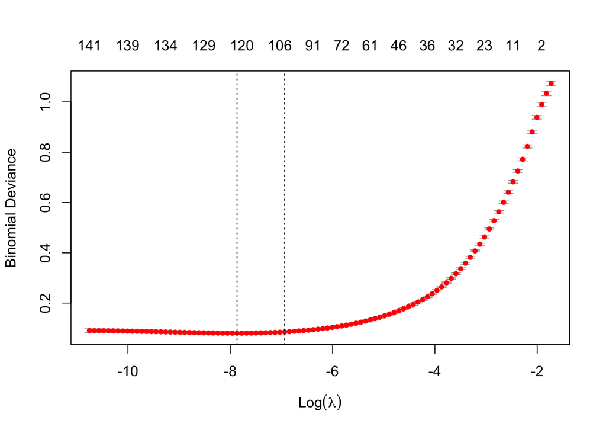

```r
#LASSO MODEL
xx <- model.matrix(phylum ~ .-1, data2)
x <- xx[training_idx, ]
y <- as.numeric(as.character(training$phylum))
#glimpse(x)


tic("LASSO")
data2_cvfit <- cv.glmnet(x, y, family = "binomial")

plot(data2_cvfit)
```

```r
LASSO_time <- toc()
```

```
## LASSO: 9.597 sec elapsed
```

```r
#coef(data2_cvfit, s = c("lambda.1se"))
length(which(coef(data2_cvfit, s ="lambda.min")>0)) #65
```

```
## [1] 59
```

다섯개 서열에 대해서 예상

```r
#MODEL EVALUATION
predi <- as.data.frame(predict.cv.glmnet(data2_cvfit, s='lambda.min', newx = x[1:5,], type='response'))
cbind(data2[as.numeric(rownames(x[1:5,])), 1], predi)
```

```
##       data2[as.numeric(rownames(x[1:5, ])), 1]  lambda.min
## 19791                                        1 0.999681722
## 7309                                         1 0.999867338
## 5216                                         0 0.002198912
## 6375                                         0 0.019760527
## 4058                                         1 0.999899891
```

```r
yhat_glmnet <- predict(data2_cvfit, s="lambda.min", newx=xx[validate_idx,],
                       type='response')
yhat_glmnet <- yhat_glmnet[,1]
pred_glmnet <- prediction(yhat_glmnet, y_obs)
#performance(pred_glmnet, "auc")@y.values[[1]]
#binomial_deviance(y_obs, yhat_glmnet)
```

나무 모델

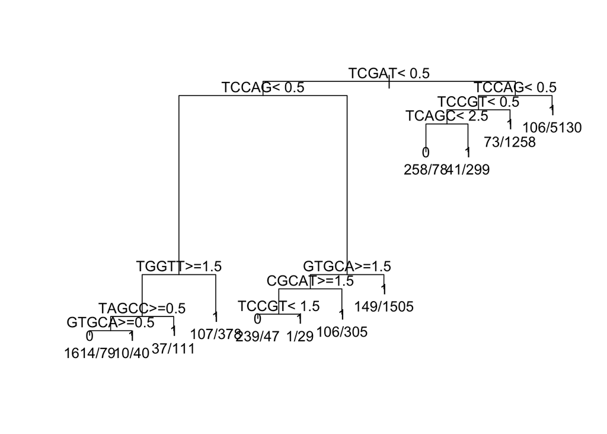

```r
#TREE MODEL
data2_tr <- rpart(phylum ~ ., data = training)
#data2_tr

#printcp(data2_tr)
#summary(data2_tr)

opar <- par(mfrow = c(1,1), xpd = NA)
plot(data2_tr)
text(data2_tr, use.n = T)
```

```r
par(opar)

#EVALUATION
yhat_tr <- predict(data2_tr, validation)
yhat_tr <- yhat_tr[,"1"]
pred_tr <- prediction(yhat_tr, y_obs)
#performance(pred_tr, "auc")@y.values[[1]]
#binomial_deviance(y_obs, yhat_tr)
```

랜덤 포레스트

```r
#RANDOM FOREST
set.seed(2305)
tic("RF")
data2_rf <- randomForest(phylum ~., training)
#data2_rf
RF_time <- toc()
```

```
## RF: 36.716 sec elapsed
```

```r
#opar <- par(mfrow=c(1,2))
#plot(data2_rf)
#varImpPlot(data2_rf)
#par(opar)

#EVALUATION
yhat_rf <- predict(data2_rf, newdata=validation, type='prob')[,'1']
pred_rf <- prediction(yhat_rf, y_obs)
#performance(pred_rf, "auc")@y.values[[1]]
#binomial_deviance(y_obs, yhat_rf)
```

부스팅

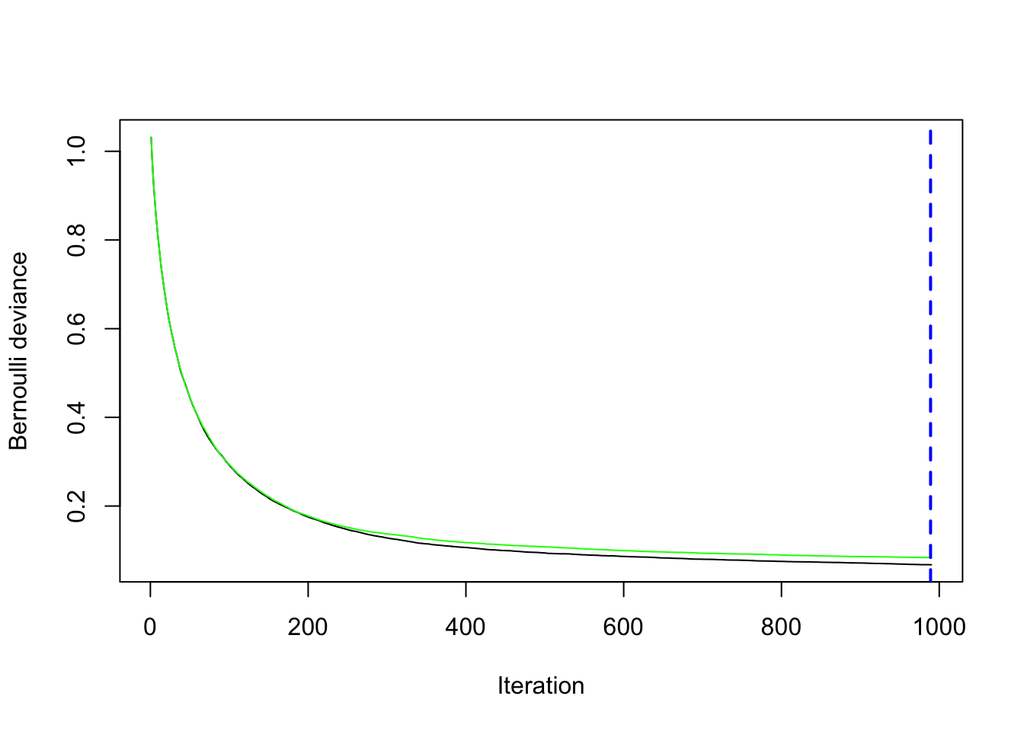

```
## [1] 989
```

```r
#BOOSTING
set.seed(2305)
tic("BOOSTING")
data2_for_gbm <-
  training %>%
  mutate(phylum=as.numeric(as.character(phylum)))
data2_gbm <- gbm(phylum ~ .,
                           data = data2_for_gbm, distribution="bernoulli",
                           n.trees=990,
                           n.minobsinnode = 1,
                           cv.folds=3,
                           verbose=T)
(best_iter = gbm.perf(data2_gbm, method="cv")) #990
```

```r
BOOSTING_time <- toc()
```

```
## BOOSTING: 23.708 sec elapsed
```

```r
#EVALUATION
yhat_gbm <- predict(data2_gbm, n.trees=best_iter, newdata=validation, type='response')
pred_gbm <- prediction(yhat_gbm, y_obs)
#performance(pred_gbm, "auc")@y.values[[1]]
#binomial_deviance(y_obs, yhat_gbm)
```

```r
(ex3_final <- data.frame(method=c('lm', 'glmnet', 'rf', 'gbm'),
           time = c(LOGISTIC_time$callback_msg,
                    LASSO_time$callback_msg,
                    RF_time$callback_msg,
                    BOOSTING_time$callback_msg),
           auc = c(performance(pred_lm, "auc")@y.values[[1]],
                   performance(pred_glmnet, "auc")@y.values[[1]],
                   performance(pred_rf, "auc")@y.values[[1]],
                   performance(pred_gbm, "auc")@y.values[[1]]),
           bin_dev = c(binomial_deviance(y_obs, yhat_lm),
                       binomial_deviance(y_obs, yhat_glmnet),
                       binomial_deviance(y_obs, yhat_rf),
                       binomial_deviance(y_obs, yhat_gbm))))
```

```
##   method                         time       auc  bin_dev
## 1     lm  LOGISTIC: 2.017 sec elapsed 0.9987319 297.7155
## 2 glmnet     LASSO: 9.597 sec elapsed 0.9989139 278.0363
## 3     rf       RF: 36.716 sec elapsed 0.9994395 737.8864
## 4    gbm BOOSTING: 23.708 sec elapsed 0.9985275 321.8731
```

```r
cbind(ex2_final, ex3_final)
```

```
##   method                           time       auc  bin_dev method
## 1     lm   LOGISTIC: 219.47 sec elapsed 0.9990533 238.8066     lm
## 2 glmnet      LASSO: 18.317 sec elapsed 0.9997186 113.6695 glmnet
## 3     rf        RF: 373.869 sec elapsed 0.9996336 576.5199     rf
## 4    gbm BOOSTING: 1079.283 sec elapsed 0.9995689 139.3133    gbm
##                           time       auc  bin_dev
## 1  LOGISTIC: 2.017 sec elapsed 0.9987319 297.7155
## 2     LASSO: 9.597 sec elapsed 0.9989139 278.0363
## 3       RF: 36.716 sec elapsed 0.9994395 737.8864
## 4 BOOSTING: 23.708 sec elapsed 0.9985275 321.8731
```

##### 3-1. multivariative by binomial data

LASSO 모형을 이용해서 특정 16S 서열의 phylum을 예상하기

```r
# number of phyla which have more than 100, 1000, 10000 freq
phylum_table %>%
  summarize(more_than_100 = n_distinct(phylum_table %>% filter(Freq > 100)),
            more_than_1000 = n_distinct(phylum_table %>% filter(Freq > 1000)),
            more_than_10000 = n_distinct(phylum_table %>% filter(Freq > 10000))
  ) #120, 38, 5
```

```
## # A tibble: 1 × 3
##   more_than_100 more_than_1000 more_than_10000
##           <int>          <int>           <int>
## 1           119             38               5
```

phylum의 종류, 서열의 수를 고려하여 서열 수 1,000개를 기준으로 한다. (38가지 phylum)  
데이터 내의 38가지의 phylum에 대해서 1,000개씩 서열을 추출한 후 해당 phylum 1000개, others 1000개가 연속되게 오도록 서열 pool을 만든다.

```r
#random 100 sequences of each phylum
filtered_phylum_table <- phylum_table %>% filter(Freq >= 1000)
#filtered_phylum_table2 <- phylum_table %>% filter(Freq <= 100, !is.na(phylum)) # 196 phylum
sampled_phylum_seq <- data.frame(matrix(nrow=0, ncol=2))
colnames(sampled_phylum_seq) <- c('phylum', 'sequence')
for (i in 1:38){
  sampled_phylum_seq <-
    rbind(sampled_phylum_seq, phylum_seq %>%
            filter(phylum == filtered_phylum_table$phylum[i]) %>%
            sample_n(1000))
}
glimpse(sampled_phylum_seq)
```

```
## Rows: 38,000
## Columns: 2
## $ phylum   <chr> "acidobacteria", "acidobacteria", "acidobacteria", "acidobact…
## $ sequence <chr> "AACGCTGGCGGCGTGCCTAACACATGCAAGTCGAACGCGAAAGTTCCTTCGGGAATGAGT…
```

```r
phylum_seq_pool <- data.frame(matrix(nrow=0, ncol=2))
for (i in 1:38){
  target <- sampled_phylum_seq %>%
    filter(phylum == filtered_phylum_table$phylum[i])
  learn <- sampled_phylum_seq %>%
    filter(phylum != filtered_phylum_table$phylum[i]) %>%
    sample_n(1000)
  target_learn <- rbind(target, learn)
  phylum_seq_pool <- rbind(phylum_seq_pool, target_learn)
}
dim(phylum_seq_pool)
```

```
## [1] 76000     2
```

```r
phylum_table %>% filter(Freq >= 1000)
```

```
## # A tibble: 38 × 2
##    phylum            Freq
##    <chr>            <int>
##  1 acidobacteria     3136
##  2 acidobacteriota   8706
##  3 actinobacteria    8870
##  4 actinobacteriota 29965
##  5 annelida          1216
##  6 arthropoda        8770
##  7 ascomycota        4291
##  8 bacteroidetes     8249
##  9 bacteroidota     41769
## 10 basidiomycota     2123
## # ℹ 28 more rows
```

##### 3-2 finding

총 76000개의 서열 정보를 2000개 씩 나누어 training 한 후 phylum을 찾고 싶은 16s 서열에 대해서 predict한다. 이 과정을 38번 반복해서 predict 결과를 순서대로 정렬하여 가장 유사한 phyla를 순서대로 확인한다.

```r
#example <- phylum_seq %>% filter(phylum == "acidobacteriota") %>%
#  sample_n(1)

example <- readDNAStringSet("/Users/chungminkim/Downloads/sequence-2.fasta")
# e.coli - proteobacteria

example <- data.frame(id=names(example),sequences=as.character(example))
colnames(example) <- c('phylum', 'sequence')

result <- data.frame(matrix(nrow=0, ncol=2))
tic("finding")
for (i in 1:38){
  data <- phylum_seq_pool[(2000*i-1999):(2000*i),]
  #data <- phylum_seq_pool[1:200,]
  data <- rbind(data, example)

  r16Sstr <- DNAStringSet(data$sequence)
  k5fq = oligonucleotideFrequency(r16Sstr, width=5)

  data <- cbind(data[,1], k5fq)
  colnames(data)[1]<-'phylum'
  #as_tibble(data)
  #data$phylum <- factor(ifelse(data$phylum == phylum_seq_pool[200*i-199,1], 0, 1))
  data[1:1000,1] <- 0
  data[1001:2001,1] <- 1
  cor_matrix <- cor(data[,c(2:1025)])
  cor_matrix_rm <- cor_matrix
  cor_matrix_rm[upper.tri(cor_matrix_rm)] <- 0
  diag(cor_matrix_rm) <- 0


  #pairs.panels(data[,c(2:11)],
  #             method = "pearson",
  #             hist.col = "#00AFBB",
  #             density = TRUE,
  #             ellipses = TRUE)

  data_new <- data[ , !apply(cor_matrix_rm,
                             2,
                             function(x) any(abs(x) > 0.30))]

  #pairs.panels(data_new[,c(1:10)],
  #             method = "pearson",
  #             hist.col = "#00AFBB",
  #             density = TRUE,
  #             ellipses = TRUE
  #)


  data2 <- cbind(data[,1], data_new)
  colnames(data2)[1]<-'phylum'

  example2 <- data2[2001, ]
  data2 <- data2[1:2000, ]


  #TRAINING
  set.seed(2306)
  n <- nrow(data2)
  idx <- 1:n
  training_idx <- sample(idx, n * .60)
  idx <- setdiff(idx, training_idx)
  validate_idx <- sample(idx, n * .20)
  test_idx <- setdiff(idx, validate_idx)
  training <- data2[training_idx,]
  validation <- data2[validate_idx,]
  test <- data2[test_idx,]

  xx <- model.matrix(phylum ~ .-1, data2)
  x <- xx[training_idx, ]
  y <- as.numeric(as.character(training$phylum))
  #glimpse(x)

  data2_cvfit <- cv.glmnet(x, y, family = "binomial")
  #plot(data2_cvfit)

  #coef(data2_cvfit, s = c("lambda.1se"))
  #coef(data2_cvfit, s = c("lambda.min"))

  #MODEL EVALUATION


  #######
  example2 <- example2[1, 2:(ncol(example2))]
  pre <- as.data.frame(predict.cv.glmnet(data2_cvfit, s='lambda.min',
                                         newx = as.double(example2), type='response'))

  result <- rbind(result, pre)
  #######

  #yhat_glmnet <- predict(data2_cvfit, s="lambda.min", newx=xx[validate_idx,],
  #                       type='response')
  #yhat_glmnet <- yhat_glmnet[,1]
  #pred_glmnet <- prediction(yhat_glmnet, y_obs)
  #performance(pred_glmnet, "auc")@y.values[[1]]
  #binomial_deviance(y_obs, yhat_glmnet)
}
finding_time <- toc()
```

```
## finding: 64.383 sec elapsed
```

```r
#data.frame(time=c(finding_time$callback_msg))

result
```

```
##    lambda.min
## 1  0.83823933
## 2  0.95623961
## 3  0.91580107
## 4  0.92334060
## 5  0.99994725
## 6  0.99983580
## 7  0.99816965
## 8  0.92094703
## 9  0.95033895
## 10 0.99964975
## 11 0.65915294
## 12 0.97484027
## 13 0.64248237
## 14 0.99999425
```

[output cut: 24 more lines]

```r
phylum_seq_pool[as.vector(which.min(result[,1])) * 2000 - 1999, 1]
```

```
## # A tibble: 1 × 1
##   phylum
##   <chr>
## 1 proteobacteria
```

```r
rank <- cbind(filtered_phylum_table$phylum, result)
head(arrange(rank, by_group=lambda.min))
```

```
##   filtered_phylum_table$phylum lambda.min
## 1               proteobacteria 0.02066498
## 2                  chloroflexi 0.64248237
## 3             bdellovibrionota 0.65915294
## 4               fusobacteriota 0.69814215
## 5                  myxococcota 0.81009659
## 6             desulfobacterota 0.81634312
```